# Wizard Wells: Formatting

Jill Deines

April 11, 2018

Goal: Load well data from Kansas’s WIZARD database, explore dataset, and format for subsequent use.

Update 5/27/2018: removing bad well flagged by Jim Butler

Note: well data is not included in this repo to leave personal data access to the management of the KGS and WIZARD database. The data used here (site and wlevel data) was downloaded for GMD4 on April 11, 2018 from http://www.kgs.ku.edu/Magellan/WaterLevels/index.html

**R Packages Needed**

```r
library(tidyverse) # for ggplot2, tidyr, dplyr
library(sf)
library(lubridate)

# get filepath to repo on local system
mainDir <- '/Users/deinesji/Documents/code_git/1phd/DeinesEtAl2019_ERL_lema1'
```

# Load Data

## Study Area Boundaries

```r
gisDir <- paste0(mainDir, '/data/GIS/boundaries')
datum <- 4269 #NAD83 = 4269

# load and re-project to NAD83 (to match WIZARD lat/long)
sheridan <- read_sf(paste0(gisDir,'/Sheridan6_fromKGS_sd6.shp')) %>%
  st_transform(4269)
null9 <- read_sf(paste0(gisDir,'/Sheridan_Null_Geo9.shp')) %>%
  st_transform(4269) %>%
  st_buffer(0)
```

```
## dist is assumed to be in decimal degrees (arc_degrees).
```

```r
gmd4 <- read_sf(paste0(gisDir,'/KS_GMD4.kml')) %>%
  st_transform(4269)

# combine study areas
aoi <- sheridan %>%
  mutate(masterid = 'sheridan') %>%
  select(masterid) %>%
  rbind(., null9 %>% select(masterid))

# buffer the study regions and dissolve (to filter wells for kriging)
aoiBuff <- aoi %>%
  st_transform(5070) %>%
  st_buffer(10000) %>%
  st_transform(4269) %>%
  st_union() %>%
  st_sf()
names(aoiBuff) <- 'geometry'
st_geometry(aoiBuff) <- 'geometry'
aoiBuff$masterid = 'buffer'

# # export for external data processing
# write_sf(aoiBuff, paste0(gisDir,'/Combined_Null9_S6_10kmBuff.shp'))

# punch holes in buffer
buffHole <- st_difference(aoiBuff, sheridan)
```

```
## although coordinates are longitude/latitude, st_difference assumes that they are planar
```

```r
buffHoles <- st_difference(buffHole, null9) %>% select('masterid')
```

```
## although coordinates are longitude/latitude, st_difference assumes that they are planar
```

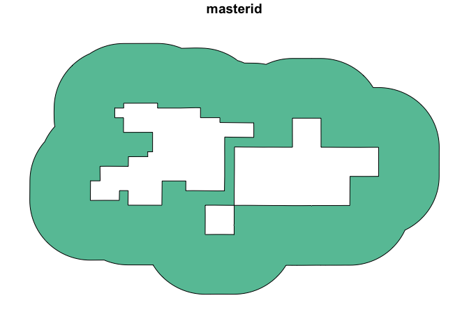

```r
plot(buffHoles)
```

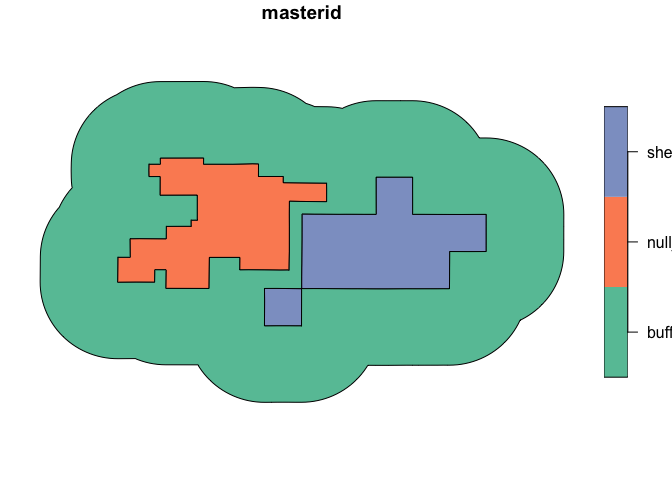

```r
# new buffered aoi polygons
aoi2 <- aoi %>%
  rbind(., buffHoles)
plot(aoi2)
```

```r
# # export for external data processing
# write_sf(aoi2, paste0(gisDir,'/Combined_Null9_S6_10kmBuff_indvlPolys.shp'))
```

## Well Data

site and wlevel data downloaded for GMD4 on April 11, 2018 from http://www.kgs.ku.edu/Magellan/WaterLevels/index.html

```r
wellDir <- paste0(mainDir, '/data/wellData/WIZARD')
siteFile <- 'raw/sites20180412183715707_GMD4_depthWells.txt'
wlevelFile <- 'raw/wlevel20180412183715707_GMD4_depthWells.txt'

# load site locations
sites <- read_csv(paste0(wellDir,'/',siteFile)) %>%
  select(c(USGS_ID, LATITUDE, LONGITUDE,
           LAND_SURFACE_ALTITUDE, LAND_SURFACE_ALTITUDE_ACCURACY,
           ALTITUDE_DATUM, USE_OF_SITE_PRIMARY,
           USE_OF_WATER_PRIMARY))
# load water levels
wlevels <- read_csv(paste0(wellDir,'/',wlevelFile)) %>%
  select(c(USGS_ID,  MEASUREMENT_DATE_AND_TIME, DEPTH_TO_WATER, ACCURACY_CODE, STATUS))
```

Note parsing errors aren’t a problem

## Subset wells for study area

Hm maybe with a buffer in the future?

```r
# spatialize well dataset
sitesLL <- st_as_sf(sites, coords = c('LONGITUDE','LATITUDE'), crs = 4269)

# extract points in both aois
wellsIn <- st_join(sitesLL, aoi2) %>% filter(!is.na(masterid))
```

```
## although coordinates are longitude/latitude, st_intersects assumes that they are planar
```

```r
# # plot
# plot(aoi2, main='water level wells, any year')
# plot(wellsIn[2], add=TRUE, col='black')
```

## Join Water Level Data and Drop Excess

Add water level data to site wells; parse some date columns. Keep only relevant columns

```r
# add water levels for subsetted wells
wellsInData <- wellsIn %>%
  left_join(wlevels, by = 'USGS_ID')

# make some date columns
wellsInData$Date <- mdy(wellsInData$MEASUREMENT_DATE_AND_TIME)
wellsInData$DOY <- yday(wellsInData$Date)
wellsInData$Year <- year(wellsInData$Date)
```

## Remove well

USGS ID - 392124100364001 per communication with Jim

```r
# check if well is in dataset
392124100364001 %in% wellsInData$USGS_ID
```

```
## [1] TRUE
```

```r
# remove well, reduce columns
wellsInData2 <- wellsInData %>%
  filter(USGS_ID != 392124100364001) %>%
  select(c(USGS_ID, masterid, Date, DOY, Year, DEPTH_TO_WATER,
           LAND_SURFACE_ALTITUDE, STATUS, ACCURACY_CODE))
```